# Preliminary Loading and Calcuation

In this notebook, I generate various validation metrics and examine the output of the recommender system using subsets of the feature vectors (full model, edge info only, color only, and autoencoder only) to get a sense for why it works as it does. First I load some preliminaries.

```python
import os, pickle
import numpy as np
import pandas as pd
import seaborn as sns
import matplotlib.pyplot as plt

%matplotlib inline
%load_ext autoreload
%autoreload 2

os.chdir("/home/dawnis/Dropbox/Insight/SmartMirror_Demo/")
```

```python
from src.fashion_tools import DeepFashion_Attributes

#first, generate a dictionary that breaks down each

with open('models/img_attr_sparse.pkl', 'rb') as S:
    img_attr_values = pickle.load(S)

with open ('models/img_attr_rows.pkl', 'rb') as S:
    img_attr_rows = pickle.load(S)

with open('models/img_attr_columns.pkl', 'rb') as S:
    img_attr_columns = pickle.load(S)

img_attr_values = img_attr_values.toarray()
img_attr_df = pd.DataFrame(img_attr_values, columns = img_attr_columns, index=img_attr_rows)


img_attr_sum = img_attr_df.sum(axis=0)

img_attr_df.head(5)
```

# Validation Using Independent Attribute Labels

I use independent hand-labeled attributes associated with the DeepFashion dataset to produce some valdiation metrics. Below, I calculate the frequency of some of thses attributes (which include various aspects of Texture, Fabric, Part, Shape and Style) within the set of Tops from the data set. For example, the frequency of the first attribute (A-Line Shape) is 0.00089.

```python
att_vector = DeepFashion_Attributes("Top", img_attr_df)
relative_frequency = att_vector.sum(axis=0)/att_vector.shape[0]
```

```python
relative_frequency[0]
```

```
0.0008930343322087716
```

## Baseline P(One or More Matching Attributes)

Using the raw frequency of each of the 1000 attibutes, we can calculate the probability that any two items have one or more attributes in common (probOneRandom below) or any 5 items have an attribute in common with some other item (probFiveRandom below). This turns out to be 15.4% and 56.6% respectively

```python
probOneRandom = 1 - np.prod(1 - relative_frequency** 2)
probFiveRandom = 1 - np.prod( ( 1 -  relative_frequency ** 2  ) ** 5)
print(probOneRandom)
print(probFiveRandom)
```

```
0.15376834640335058
0.5660433667235547
```

## P(One or More Matching) using full or partial feature vector-based similarity

Image-based feature vectors are completely independent of the hand-label attributes. Therefore we can examine how well the top match for an input, or the top 5 matches, perfrom using the P(One or More Matching Attributes) metric. I load pre-computed match vectors (which were produced by examining the number of matching attributes for the top matches produced by the model for each image in the data set) and then calculating the probability based on the overall frequency of matches.

```python
#dvAll = np.load("features/u_current_feature_vector_dotv.npy")
#dvHog = np.load("features/u_hog_dotv.npy")
#dvAE = np.load("features/u_encoder_dotv.npy")
#dvHSV = np.load("features/u_hsv_dotv.npy")

pAll = pickle.load(open( "u_current_feature_vector_ProbAttMatch.p", 'rb' ) )
pHOG = pickle.load(open( "u_hog_ProbAttMatch.p", 'rb' ) )
pHSV = pickle.load(open( "u_hsv_ProbAttMatch.p", 'rb' ) )
pAE = pickle.load(open( "u_encoder_ProbAttMatch.p", 'rb'))
```

```python
items_to_examine = [pAll, pHOG, pHSV, pAE]

for pb in items_to_examine:
    pbTopMatch = np.zeros((1,1000))
    pbFiveMatch = np.zeros((1,1000))
    for obj in pb:
        objMat = obj.toarray()
        pbTopMatch += objMat[0]
        pbFiveMatch += np.max(objMat, axis=0)

    pbTopMatch /= len(pb)
    pbFiveMatch /= len(pb)

    pbOne = 1 - np.prod(1-pbTopMatch)
    pbFiveMatch = 1 - np.prod(1-pbFiveMatch)

    print("P(One or More) =  {:2.2f} and P(One or More) in five = {:2.2f}".format(pbOne*100, pbFiveMatch*100))
```

```
P(One or More) =  46.44 and P(One or More) in five = 72.01
P(One or More) =  44.99 and P(One or More) in five = 70.58
P(One or More) =  36.05 and P(One or More) in five = 65.00
P(One or More) =  37.15 and P(One or More) in five = 64.83
```

## Results for P(One or More Matching)

As you can see above, the probabilities differ depending on whether we use all features, just edges (HOG or Histogram of Oriented Gradients), Color (HSV) or Autoencoder. It seems that HOG performs almost as well as the full model. This may be due to the fact that many of the attributes describe pattern or shape information (such as horizontal stripes on the fabric) which HOG is particularly sensitive to. That is, this may be a specific artifact of the validation metric (e.g. there are no attributes which are "Red Color" ).

## Examination of top N choice overlaps using either image-based feature vectors or hand-labeled attributes to compute similarity

Another way of examining the similarity between choices produced by the model and using the independent hand-labeled features is to compare how many of the Top N choices overlap using either the model-based features or hand-labeled attributes to compute distance.

That is, for a given item X, how many of the top N choices produced by the recommender model and the top N choices by finding the most similar items in attribute space overlap?

To produce a single metric for this, one can simply compute the # of intersecting elements in the two returned sets for each item (pre-computed for this notebook as *overlap top ten*.

```python
overlap_top_ten = np.load("features/overlap_scores10.npy")
```

```
5
```

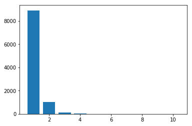

```python
xhist, bn = np.histogram(overlap_top_ten, range=(0,10), bins=10)
plt.bar(bn[1:], xhist)
print(np.max(overlap_top_ten))
```

A histogram shows that (perhaps disappointingly) that most items do not have any overlap with their top ten choices in attribute space. We will explore why this might be when we visualize the results below. However, approximately 10% of items have one or more intersecting in the top 10 matches.

```python
from src.fashion_tools import category_cloth_attr
attr_cloth = "labels/list_attr_cloth.txt"

attrDict = category_cloth_attr(attr_cloth)

got = np.where(overlap_top_ten>0)[0]
gotsub = img_attr_df.iloc[got].copy()
gotsubsum = gotsub.sum(axis=0)
```

```python
print(gotsub.shape[0])
1162/10078.
```

```
1162
```

```
0.11530065489184362
```

The bit of code above just confirms that 11.5% of items had one or more items matching. I examine whether the items that do show overlap have any commonalities. To do this, I take advantage of another label that comes with the DeepFashion data set, each of the 1000 attributes comes with a label which describes whether it pertains to 1.) Texture, 2.) Part, 3.) Shape, 4.) Part or 5.) Style. I compute the overall frequency of this attribute categories within the 10,078 Tops and then determine if any of the items which performed better than 0 on the *overlapping recommendations* task are over-represented in any of the particular categories

```python
gotsubsum.drop(index = [row_name for row_name in gotsubsum.index if gotsubsum[row_name]==0], inplace=True)
```

```python
share_category_h = np.zeros(5)
for key in gotsubsum.keys():
    share_category_h[ attrDict[key] -1 ] += gotsubsum[key]

print(share_category_h)
```

```
[ 732. 1111.  574. 1158.  538.]
```

This is the frequency of items that have overlapping recommendations in each of the five attribute-type categories. We can compare these frequencies to the overall frequencies of each attribute-type (categorized by 1.) Texture, 2.) Part, 3.) Shape, 4.) Part or 5.) Style) in order to see if any of these are over-represented by comparison to the others.

```python
total_numbers_h = np.zeros(5)
att_vector_sum = att_vector.sum(axis=0)

for key in att_vector_sum.keys():
    total_numbers_h[ attrDict[key] -1 ] += att_vector_sum[key]

print(total_numbers_h)
print(share_category_h/total_numbers_h)
```

```
[8047. 8419. 7771. 6478. 5057.]
[0.09096558 0.13196342 0.07386437 0.17875888 0.10638719]
```

We can see that as a fraction of the total attribute-categories, that the one corresponding to 4.) Part seems to be over-represented (17%) relative to the rest. Here, part refers to very specific types of features in the clothing such as a type of zipper or front pocket. It could be that these types of features are picked up prominently in the visually based image features

# Qualitative assessment of recommender model performance

Here I examine the top 3 choices for a variety of input for the recommender service and also just using the hand-labeled attributes to compute similarity.

## First we load random selections and find the top 3 choices for each

```python
import random
from src.fashion_tools import rgb_image_bounding_box, DeepFashion, fashion_similarity

def compute_similarity_index(choice, fv, deepKeys, topn):
    #choice = deepKeys[index]
    similarity_scores = fashion_similarity(choice, fv, deepKeys)
    similarity_scores[deepKeys.index(choice)] = np.max(similarity_scores)
    closest = np.argsort(np.array(similarity_scores))
    return [deepKeys[matc] for matc in closest[:topn]]
```

```python
topDict = DeepFashion("Top")
deepKeys = [key for key in att_vector.index]
```

```python
fv = np.load('features/u_current_feature_vector.npy')
fv.shape
```

```
(10078, 786)
```

## Visual Comparison

Here, I plot the top 3 choices for the recommender system (columns 2-4) and using the hand-labeled attributes to compute similarity (columns 5-7).

The input images and attribute results are also titled with the attributes that they are positive for.

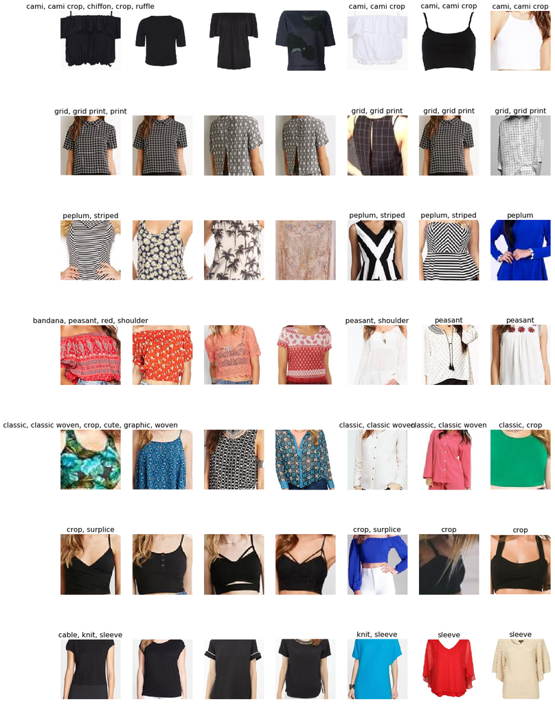

```python
fig, ax = plt.subplots(7, 7)
fig.set_figwidth(20)
fig.set_figheight(30)

dfSample = random.sample(deepKeys,7)
plt.axis('off')
fullpath_to_data = "/home/dawnis/Data/SmartMirror/DeepFashion_Data"
dfSet = [rgb_image_bounding_box("/".join([fullpath_to_data,img]), topDict[img], convert_bgr=True, autocrop=True) for img in dfSample]

for row, img in enumerate(dfSample):
    bestMatch_fv = compute_similarity_index(img, fv, deepKeys, 3)
    keyAtt = att_vector.loc[img] == 1
    attnames = img_attr_columns[keyAtt]
    ax[row][0].imshow(dfSet[row])
    ax[row][0].set_title(", ".join(attnames), size='16')
    for col, fvImg in enumerate(bestMatch_fv):
        dat = rgb_image_bounding_box("/".join([fullpath_to_data, fvImg]), topDict[fvImg], convert_bgr=True, autocrop=True)
        ax[row][col + 1].imshow(dat)
    bestMatch_av = compute_similarity_index(img, att_vector.values, deepKeys, 3)
    for col, avImg in enumerate(bestMatch_av):
        matchAtt = att_vector.loc[avImg]
        attNames_idx = keyAtt & (matchAtt == 1)
        attNames = img_attr_columns[attNames_idx]
        dat = rgb_image_bounding_box("/".join([fullpath_to_data, avImg]), topDict[avImg], convert_bgr=True, autocrop=True)
        ax[row][col + 4].imshow(dat)
        ax[row][col + 4].set_title(", ".join(attNames[:2]), size='16')

for row in range(7):
    for col in range(7):
        ax[row][col].set_xticks([])
        ax[row][col].set_yticks([])
        ax[row][col].set_axis_off()
```

## Results of Visual Comparison

The qualtiative results suggest that the model produces more visually similar matches than using the hand-labeled attributes alone! The hand-labeled attributes do not contain any color information. In addition, the attributes are rather sparse and less rich than the image-based feature vectors. For example, for the input of ["crop", "surplice"] there are probably quite a few matches that have either ["crop"] or ["surplice"] but no real way to differentiate between the quality of results that match on these dimensions

# Using Image-Based Feature Vector Subsets

How much do individual components of the model contribute to the recommender service? Here I split the feature vectors into components related to the autoencoder, edge information, and color and examine the qualitative performance of each alone.

```
(10078, 256)
(10078, 18)
(10078, 512)
```

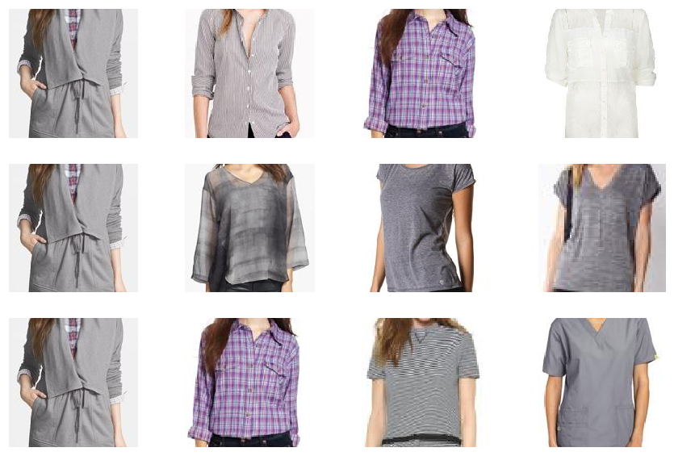

```python
#produces the top 3 matches for a randomly chosen item using only subset feature vectors
fig, ax = plt.subplots(3, 4)
fig.set_figwidth(15)
fig.set_figheight(10)

dfSample = random.sample(deepKeys,1)
plt.axis('off')
fullpath_to_data = "/home/dawnis/Data/SmartMirror/DeepFashion_Data"
dfSet = [rgb_image_bounding_box("/".join([fullpath_to_data,img]), topDict[img], convert_bgr=True, autocrop=True) for img in dfSample]

featurev_to_use = ['features/u_hog.npy', 'features/u_hsv.npy', 'features/u_encoder.npy']

for row, feature_v in enumerate(featurev_to_use):
    fv = np.load(feature_v)
    print(fv.shape)
    bestMatch_fv = compute_similarity_index(dfSample[0], fv, deepKeys, 3)
    keyAtt = att_vector.loc[img] == 1
    ax[row][0].imshow(dfSet[0])
    for col, fvImg in enumerate(bestMatch_fv):
        dat = rgb_image_bounding_box("/".join([fullpath_to_data, fvImg]), topDict[fvImg], convert_bgr=True, autocrop=True)
        ax[row][col + 1].imshow(dat)

for row in range(3):
    for col in range(4):
        ax[row][col].set_xticks([])
        ax[row][col].set_yticks([])
        ax[row][col].set_axis_off()
```

The top row shows the performance of the edge statistics-based vectors alone. We can see that the recommendations produced by this component may overfit for spurious features in the image such as the v-shaped opening in the blouse of the input image.

The middle row shows that the color-based feature vector does well in selecting similar color palettes but completely ignores shape.

Lastly, the autoencoder-based selections in the last row seems to indicate a preference for the same overall shape of the shirt but does not exhibit sensitivty to color or pattern (such as the horizontal stripes in the second choice).